# 第4回 推定と検定（標準誤差・t 値・仮説検定・信頼区間）

経済データとプログラミングII

第4回

推定と検定

引いた傾きを、どこまで信じてよいか

経済データとプログラミングII

第4回 — Topic01

標準誤差

引き直すと、傾きはどれだけ揺れる？

## 第4回の道のり

1

揺れを測る

実習：実行 データを読む準備

実習：実行 引き直しの実行

実習：写経 標準誤差

演習 4-1 期間別の標準誤差

2

揺れの何個分

実習：写経 $t$ 値

演習 4-2 期間別の $t$ 値

3

偶然か判定

実習：写経 $p$ 値

演習 4-3 期間別の $p$ 値

4

基準の範囲

いまココ — 引いた線の**傾きが、どれくらい揺れるか**を測る

## 前の回の振り返り

前の回のポイント

Q: 期間を変えて線を引くと、何が変わったか

- **前の回**: 36 年に引いた線の傾きは $-0.859$（summary の `coef`）
- **期間で切った線**: 傾きも変わり、$R^2$ は 1991〜1999 年が 0.72、2013〜2019 年は 0.02
- **残した問い**: 計算した傾きそのものを、どこまで信じてよいか

データが少し変わるだけで、数は動く。**同じことが傾きにも起きる**  
summary の `std err` から先の列を、この回で読む

## このトピックで学ぶこと

- **傾き**：この回で傾きと言ったら、**回帰直線の傾き $b_1$**
- **何をやるか**：その傾きが、データの組ごとに**どれくらい揺れるか**を測る
- **なぜ**：手元のデータは、たまたま手に入った一組にすぎない
- **いつ必須か**：係数（傾きのこと）を 1 つの数で報告するたび  
  「その数は確かか」と問われる
- **進め方**：前半は 5 人の表だけ。  
  後半で 36 年のデータに同じ手順を当てる

問い：引き直すと、傾きはどれだけ揺れる？

## 5 人の表の回帰直線

前の回までの 5 人（1 週間あたり）。バイト日数 $x$ と自習時間 $y$

[figure not shown]

たまたまこの 5 人だったから $-2.0$ なのでは？ 別の 5 人なら？

## ◼ 標本と母集団

定義

**標本**：たまたま手に入った、データの一組

**母集団**：標本を取り出した元の、見えない全体

- **今回は**：5 人の表が標本。5 人が選ばれた元の学生全体が母集団
- **知りたいのは**：母集団で線を引いたときの傾き（見えない）
- **手元にあるのは**：標本で引いた傾き $-2.0$ だけ

別の標本なら、傾きは別の数になる。その揺れの大きさを測りたい

## ◼ 引き直しの手順

別の 5 人は集め直せない  
そこで**手元の 5 人を全体の見本とみなして**引き直す（集め直す代わりの近似）

手順

STEP 1くじで 5 人を引く

STEP 2その 5 人で回帰直線を引き、傾きを出す

STEP 31000 回くり返す

STEP 41000 個の傾きの散らばり（標準偏差）を測る

- **規則 1**：引くたびに元に戻す。だから**同じ人が 2 回出てよい**
- **規則 2**：全員が同じ日数の組は線が引けないので、引き直す

## 5 人の引き直し（STEP 1・2）

[figure not shown]

引くたびに傾きが変わる：$-1.83$・$-2.46$・$-2.15$

## ✋ たしかめ 1000 回の引き直し

たしかめ

5 人の引き直しを 1000 回くり返すと、傾きはどうなるか

1. **ⓐ** ほとんど $-2.0$ のまま **ⓑ** 少し動くが、  
   プラスにはならない **ⓒ** マイナスがプラスに変わることもある
2. 1 つ選んでから、次のページで答え合わせ

⏸ PAUSE 動画を止めて $1$ 分。選んだら再生に戻る

## 1000 回の傾きの散らばり（STEP 3・4）

[figure not shown]

答えは **ⓒ**。1000 回のうち $+$ が 19 回。STEP 4 の散らばりは $0.80$

$-4$ や $+1$ の山は、引いた 5 人が 2〜3 人しか出なかった回  
（C・D や B・C・D なら $-4$, D・E なら $+1$）

## ◼ 標本の取り直しと標準誤差

[figure not shown]

今回の数は傾き。母集団からは取り直せないので、  
手元の 5 人から引き直して代わりにした（$0.80$）

## ◼ 標準誤差

定義

**標準誤差**：標本を取り直したときの、  
**標本から計算した数の揺れの大きさ**

- **今回の数は傾き**：5 人を 1000 回引き直して見積もった散らばり $0.80$
- **読み方**：別の 5 人なら、傾きは $-2.0$ からおよそ $0.80$ ほど前後しうる
- **summary では**：後半で見る `std err` の列が、この標準誤差

1 つの数で書いた傾き $-2.0$ には、いつもこの揺れが付いている

## よくある失敗 散らばりの取り違え

✗「標準誤差 ＝ データの散らばり」。名前がそっくりなので、そう思いたくなる

[figure not shown]

同じ標準偏差の物差しでも、**当てる相手が違う**  
自習時間 5 つに当てると $3.2$ で、傾き 1000 個に当てると $0.80$＝標準誤差

## デモ：標本を引き直す実験室

数の話

選び直した組ごとに、  
元の $-0.859$ と同じ計算で傾きを 1 つ出す

- **何を見るか**：別の年の組だったら、傾きはどれくらい動くか
- **図の意味**：デモの画面では、上は点と直線、  
  下は傾きのヒストグラム、右は読み出し
- **操作**：タブ 2 つ（36 点・6 点）・引き直す 1・10・100 回・戻す

ミッション 今度は 36 年で同じ手順を。6 点と 36 点で、  
ヒストグラムの幅は？ 1000 回まで引き直す

※ 次のスライドへ進むときは、デモの枠の外を一度クリックしてから ← → キーを押す

[interactive chart not shown]

## ★ 36 点と 6 点の引き直し

今度は 36 年の物価上昇率と失業率で、同じ STEP 1〜4

[figure not shown]

36 点の散らばりは $0.127$ で、6 点は $0.238$  
**ほかが同じなら、点が少ないほど揺れは大きくなりやすい**

ニュースの世論調査の「誤差」も同じ考え。聞く人を選び直したときの揺れの幅

## 式で見積もる標準誤差

- **summary の `std err`**：前に出てきた `res.summary()` の表の列（下の表）
- **何の数か**：同じ揺れを、引き直さずに**式で**見積もった値
- **引き直しとの関係**：$0.127$ と近いが一致はしない。どちらも見積もりで、  
  この先は summary の $0.135$ を使う

| summary の行 | `coef` | `std err` |
| --- | --- | --- |
| `unemployment_rate` | $-0.859$ | $0.135$ |

式の揺れが小さくなるとき

①点が線から外れていないほど

②点が多いほど

③失業率が広く散らばっているほど

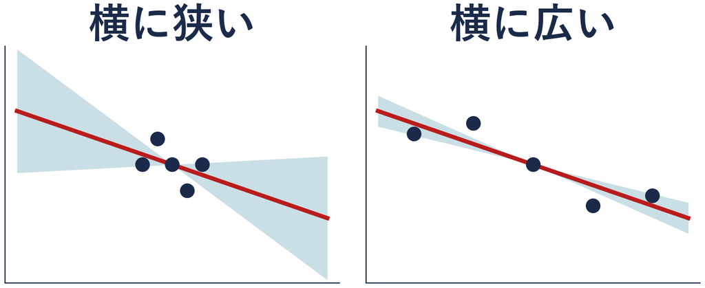

## データを読む準備のセル

```python
!pip install -q japanize-matplotlib
import japanize_matplotlib
import pandas as pd
import statsmodels.formula.api as smf
BASE = "ここに manaba の URL を貼る"
u = pd.read_csv(BASE + "unemployment_sa_monthly.csv", parse_dates=["date"])
c = pd.read_csv(BASE + "cpi_core_yoy_monthly.csv", parse_dates=["date"])
df = pd.merge(u, c, on="date").set_index("date")
df = df.resample("YS").mean()
d91 = df.loc["1991":"1999"]
d13 = df.loc["2013":"2019"]
five = pd.DataFrame({"x": [1, 2, 3, 4, 5], "y": [9, 10, 6, 2, 3]})
print(len(df), len(d91), len(d13))
```

| 行 | 書き方 | 意味 |
| --- | --- | --- |
| 1-4 | 道具を呼ぶ | 図の日本語の 2 行と、表の道具・式で書く回帰の道具 `smf` |
| 5 | `BASE = "…"` | manaba に載せた URL の**最後の / まで**を貼る |
| 6-11 | 読む・年平均・期間 | 36 年の表 `df`、1991〜1999 年の `d91`、2013〜2019 年の `d13` |
| 12-13 | 5 人の表・確かめ | 5 人の表 `five`（後のトピックで使う）。`36 9 7` と出る |

**写経せず、そのまま実行するセル**。ノートは manaba の第 4 回から Colab で開く

## 引き直しのセルの実行

- **場所**：ノートの【見るだけ：そのまま実行】のセル（引き直しを 1000 回）
- **すること**：選んで ▶ で実行するだけ（写さない）
- **くじ**：デモと同じくじの番号 42 に固定してある  
  ので、何度実行しても同じ結果

| 出る行 | 散らばり | ＋になった回 |
| --- | --- | --- |
| 5 人 | 0.8（＝0.80） | 19 |
| 36 年 | 0.127 | 0 |

5 人のヒストグラムも描かれる。前半で見た図と同じ形

## 写経 標準誤差のコード

```python
model = smf.ols("cpi_core_yoy ~ unemployment_rate", data=df)
res = model.fit()
print(res.bse)
```

| 行 | 部品 | 渡すもの | 返ってくるもの・起きること |
| --- | --- | --- | --- |
| 1-2 | **式を書く・当てはめる** | 前に書いた式と表 `df` | 当てはめた結果 `res` |
| 3 | **読む所を替える** | `params` を `bse` に（1 語） | `unemployment_rate` の行が 傾きの `std err` |

決まった部品を順にはめる**パズル**  
前の回の `print(res.params)` から、3 行目の 1 語だけ変える  
`bse`：係数（b）の standard error。`Intercept` の行は切片

## 標準誤差の写経と実行

1. **＋ コード**で空のセルを足す  
   （案内の文の下）
2. 写経の 3 行を上から写す
3. **▶** か **Shift + Enter** で実行  
   （Mac は Shift + return）
4. `unemployment_rate`  
   の行に 0.13 から  
   始まる数が出るかを見る

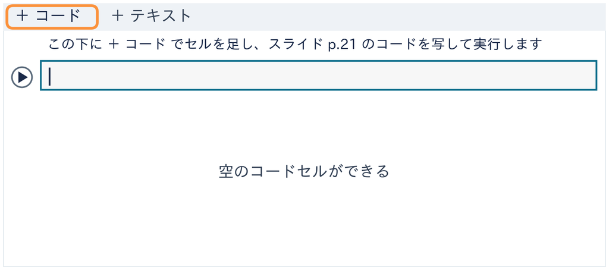

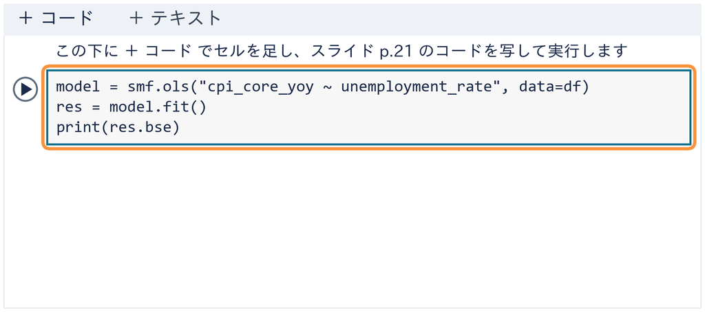

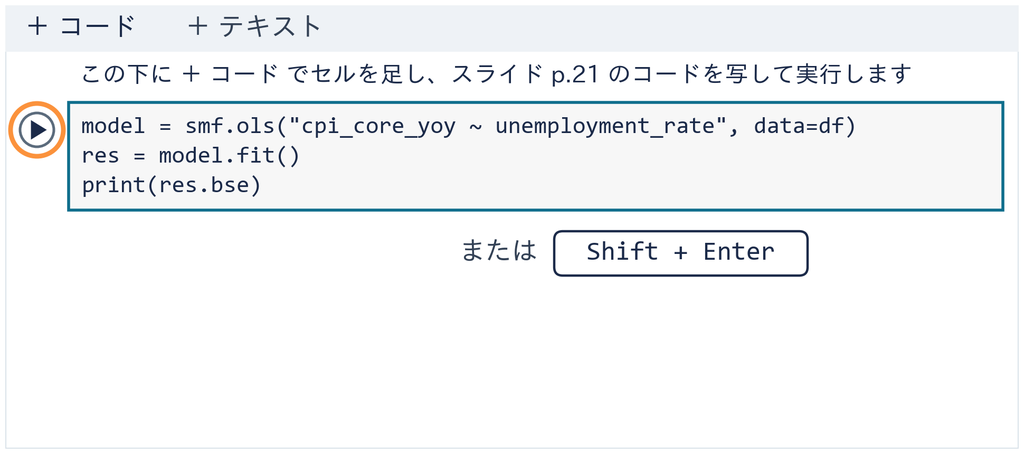

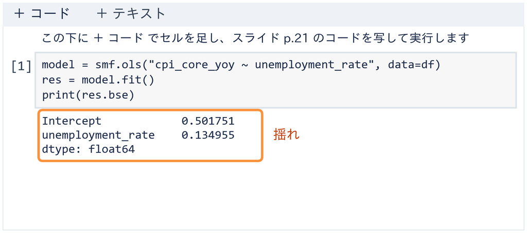

⏸ PAUSE 動画を止めて $2$ 分。0.13 から始まる数が出たら再生に戻る

## 演習 4-1 期間別の標準誤差

演習 4-1

1991〜1999 年の 9 年だけで当てると  
傾きの `std err` は 36 年の 0.135 と比べてどうなるか

```python
model = smf.ols("cpi_core_yoy ~ unemployment_rate", data=df)
res = model.fit()
print(res.bse)
```

1. **先に考える**：ⓐ 大きくなる ⓑ 小さくなる ⓒ 変わらない
2. **写して変える**：**＋ コード**のセルに上の 3 行を写し、`data=df` を `data=d91` に
3. **終わり**：答え欄に ⓐ〜ⓒ と `std err` の数（写経のセルは残す）

⏸ PAUSE 動画を止めて $3$ 分。答えを書いたら再生に戻る

## 演習 4-1 の答え

答えは **ⓐ 大きくなる**。9 年の `std err` は $0.248$（36 年の $0.135$ の約 1.8 倍）

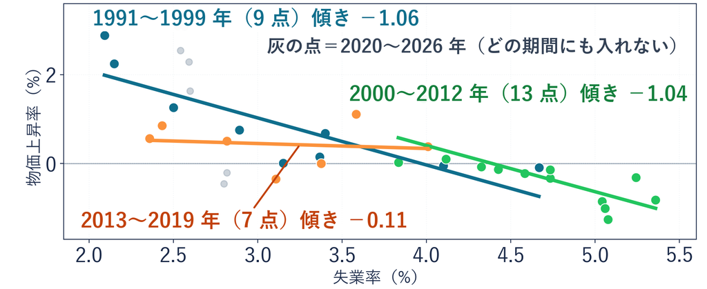

前に出てきた期間別の線。点が 36 から 9 に減ると、  
揺れ（`std err`）は約 1.8 倍

## まとめ

- 手元のデータは**標本**。引き直すと傾きは揺れる（5 人で $0.80$）
- 揺れの大きさが**標準誤差**（36 年の `std err` は $0.135$）
- ほかが同じなら、  
  点が少ないほど揺れは大きくなりやすい（9 年で $0.248$）
- コードは読む所を `params` から `bse` に替えるだけ

では、36 年の傾き $-0.859$ は、揺れの何個分 0 から離れているか。  
次は揺れを物差しにする

経済データとプログラミングII

第4回 — Topic02

$t$ 値

傾きは、揺れの何個分？

## 第4回の道のり

1

揺れを測る

実習：実行 データを読む準備

実習：実行 引き直しの実行

実習：写経 標準誤差

演習 4-1 期間別の標準誤差

2

揺れの何個分

実習：写経 $t$ 値

演習 4-2 期間別の $t$ 値

3

偶然か判定

実習：写経 $p$ 値

演習 4-3 期間別の $p$ 値

4

基準の範囲

いまココ — 傾きを、**基準から揺れの何個分**で測る

## このトピックで学ぶこと

- **傾き**：この回の傾きは、**回帰直線の傾き $b_1$**
- **何をやるか**：傾きを「基準から、揺れ（標準誤差）の何個分」で測る
- **なぜ**：傾きの大きさは単位で変わり、  
  揺れに埋もれているかも分からない
- **出てくる所**：summary の `t` の列は、この数
- **進め方**：前半は 5 人の表だけ。後半で 36 年に同じ 3 STEP を当てる

問い：傾きは、揺れの何個分？

## 傾きの大きさと単位

5 人の傾き $-2.0$ は、大きいのか（符号を外した大きさで）

| 人 | A | B | C | D | E | 傾き |
| --- | --- | --- | --- | --- | --- | --- |
| バイト日数 $x$（日） | 1 | 2 | 3 | 4 | 5 |  |
| 自習時間（時間） | 9 | 10 | 6 | 2 | 3 | $-2.0$ |
| 自習時間（分） | 540 | 600 | 360 | 120 | 180 | $-120$ |

1 時間＝60 分なので、分の行は時間の 60 倍。傾きも $-2.0 \times 60 = -120$  
**同じ 5 人なのに、傾きの大きさは単位で変わる**

## ◼ 揺れの個数の求め方

定義

**揺れの個数**：傾きが、**基準**から揺れ（標準誤差）の**何個分**離れているか
$$\text{個数} = (\text{傾き} - \text{基準}) \div \text{揺れ}$$

手順

STEP 1傾きを出す

STEP 2揺れ（標準誤差）を出す

STEP 3傾きから基準を引き、揺れで割る

- **基準**：比べる相手の傾き。この授業の例では **0**  
  （上がりも下がりもしない、関係が無いときの傾き）
- **なぜ 0 と比べる**：関係が無いのに偶然この傾きになっただけかを  
  確かめたい（次のトピック）

## ◼ 式で出す揺れ

STEP 2

STEP 2 の揺れは、**summary と同じ式で出す揺れ**。5 人は $0.58$

- **何から出すか**：点が線 $\hat y = 12.0 - 2.0x$ からどれだけ外れているか  
  （A〜E で $-1$・$+2$・$0$・$-2$・$+1$）
- **計算**：外れの二乗の和 $10$ → $\sqrt{10 \div 3} \div \sqrt{10} = 0.577\ldots$  
  （$3 = 5 - 2$, 右の $10$ は日数の離れの二乗の和 $4+1+0+1+4$）
- **大きくなるとき**：点が線から外れているほど大きい  
  （ふだんの計算はコンピュータに任せる）
- **どの表にも**：引き直しをしなくても、同じ計算で出せる

この先は、この式の揺れで $t$ を出す

## 引き直しの揺れとの違い

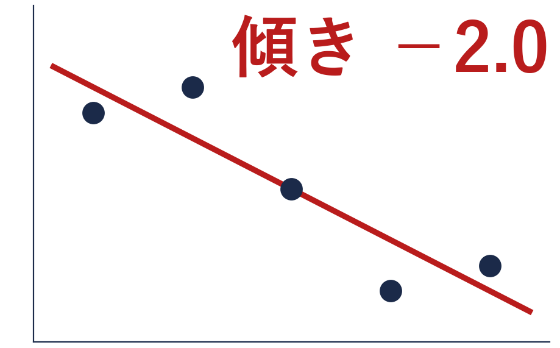

**思い出し**：5 人で引いた線の傾きは $-2.0$  
前のトピックで 5 人を 1000 回引き直すと、  
傾きは $0.80$ ほど揺れた（下の図）

[figure not shown]

$0.80$ が式の揺れ $0.58$ より大きいのは、2〜3 人だけの組で傾きが大きく振れるから  
どちらも傾きの揺れの見積もりで、**点が多いと 2 つは近づく**（後半の 36 年で見る）

## 5 人の揺れの個数（STEP 1〜3）

STEP 1 傾き $-2.0$（5 人の線） STEP 2 揺れ $0.58$（式の揺れ） 基準は 0

[figure not shown]

STEP 3 $(-2.0 - 0) \div 0.577\ldots \approx -3.46$ → 基準 0 から 3.46 個分

0.58 は丸めた数。割るときは丸める前の数で割る  
（丸めた 0.58 で割ると −3.45）

## 分で測った揺れの個数

分で測ると傾きは $-120$。式の揺れも 60 倍で約 $34.6$

[figure not shown]

$(-120 - 0) \div 34.6\ldots \approx -3.46$

**単位を替えても、個数は変わらない**（時間でも分でも 3.46 個分）

## ◼ $t$ 値

定義

この揺れの個数を **$t$ 値**と呼ぶ
$$t = (\text{傾き} - \text{基準}) \div \text{揺れ（標準誤差）}$$

- **今回は**：5 人は基準 0 で $t \approx -3.46$（時間でも分でも同じ）
- **基準 0 の意味**：傾き 0（その列と関係が無い）と比べている
- **符号**：傾きの向き。**大きさ**：基準からの離れ（揺れの何個分）
- **単位が消える**：傾きも揺れも「時間／日」。割ると単位が消える

単位の違う傾きどうしも、$t$ なら同じ物差しで比べられる。  
基準は 0 でなくてもよい（この回の後半で使う）

## ✋ たしかめ 揺れと個数

たしかめ

同じ傾き $-2.0$（基準 0）で、揺れが変わると何個分になるか

1. 揺れが $0.5$ なら **ⓐ** 1.0 個分 **ⓑ** 2.5 個分 **ⓒ** 4.0 個分
2. 揺れが $2.0$ なら **ⓐ** 1.0 個分 **ⓑ** 2.5 個分 **ⓒ** 4.0 個分
3. 2 つ選んでから、次のページで答え合わせ

⏸ PAUSE 動画を止めて $1$ 分。2 つ選んだら再生に戻る

## たしかめの答え

[figure not shown]

揺れ $0.5$ なら **ⓒ 4.0 個分**、揺れ $2.0$ なら **ⓐ 1.0 個分**  
同じ傾きでも、揺れが小さいほど個数は大きい

## よくある失敗 傾きの急さと $t$ 値の混同

✕ 傾きが急なら $t$ も大きいはず

割られる側は傾き

揺れを見ずに  
傾きだけで決めている

○ 揺れとの比で決まる

同じ $-2.0$ でも  
揺れ 0.5 なら 4.0 個分

揺れ 2.0 なら 1.0 個分  
傾きが同じでも  
個数は揺れで変わる

傾きの急さだけでは決まらない。**揺れで割った個数**で見る

## ★ 36 年の $t$ 値

今度は 36 年で、同じ 3 STEP（基準 0）  
傾き $-0.859$＝失業率 1 ポイントで物価上昇率が 0.859 ポイント下がる

[figure not shown]

式の揺れ $0.135$ で割ると $(-0.859 - 0) \div 0.135 \approx -6.36$＝summary の `t`

引き直しの揺れ $0.127$ で割っても約 $-6.8$. 36 年では 2 つの揺れが近い

## 5 人と 36 年の $t$ 値の比較

|  | 傾き | 揺れ（式の揺れ） | $t$（基準 0） |
| --- | --- | --- | --- |
| 5 人 | $-2.0$ | $0.58$ | $-3.46$ |
| 36 年 | $-0.859$ | $0.135$（`std err`） | $-6.36$ |

数だけ見ると、5 人の $-2.0$ のほうが大きく見える  
でも揺れで割ると、**36 年のほうが基準 0 から遠い**（3.46 個分と 6.36 個分）

論文やレポートの回帰の表に並ぶ「t」も、この読み方

## 写経 $t$ 値のコード

```python
model = smf.ols("cpi_core_yoy ~ unemployment_rate", data=df)
res = model.fit()
print(res.params / res.bse)
print(res.tvalues)
```

| 行 | 部品 | 渡すもの | 返ってくるもの・起きること |
| --- | --- | --- | --- |
| 1-2 | **式を書く・当てはめる** | 前の写経と同じ 2 行 | 36 年の結果 `res` |
| 3 | **割る（STEP 3・基準 0）** | 係数 `params` を揺れ `bse` で | `unemployment_rate` の行に −6.36… |
| 4 | **summary の `t`** | `tvalues` | 3 行目と同じ数が出る |

前のトピックと同じノートの続き  
（開き直したら上のセルから順に ▶）  
1・2 行目も写し直す  
（演習 4-1 で `res` が 1991〜1999 年の結果に替わっているため）

## $t$ 値の写経と実行

1. **＋ コード**で空のセルを足す  
   （案内の文の下）
2. 前のページの 4 行を上  
   から写す
3. **▶** か **Shift + Enter** で実行  
   （Mac は Shift + return）
4. 2 つの出力で `unemployment_rate`  
   の行が同じ数かを見る

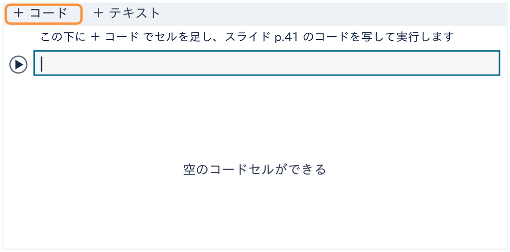

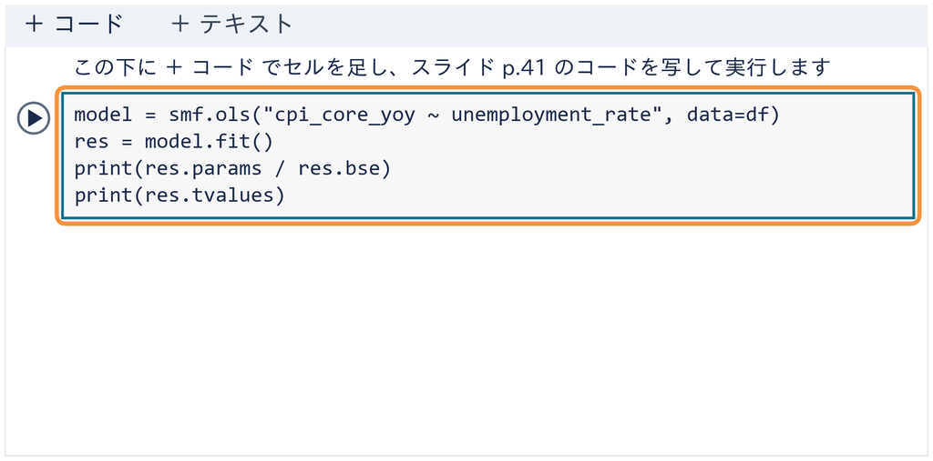

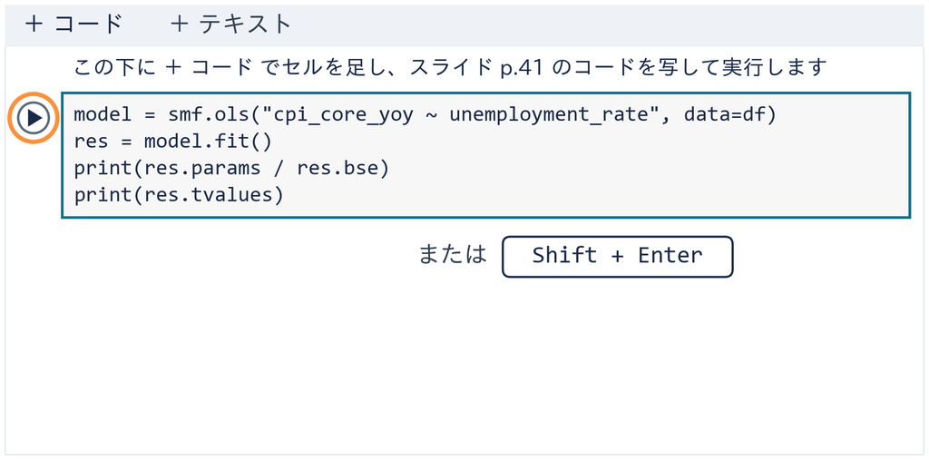

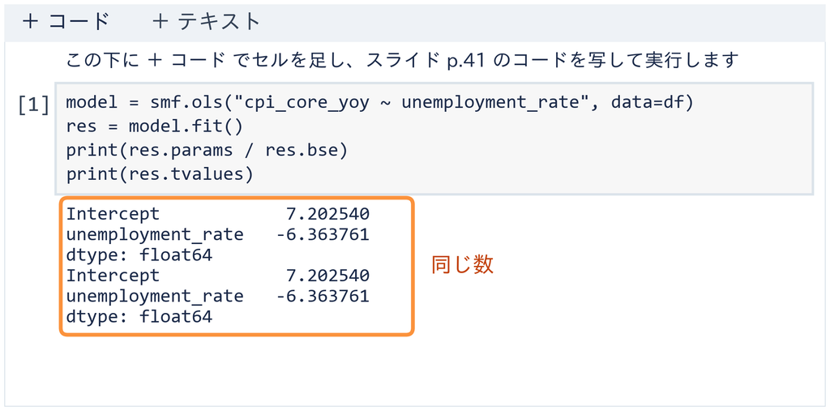

⏸ PAUSE 動画を止めて $2$ 分。同じ数が 2 回出たら再生に戻る

## 演習 4-2 期間別の $t$ 値

演習 4-2

9 年の $t$ の大きさは、36 年の 6.36 と比べてどうなるか

```python
model = smf.ols("cpi_core_yoy ~ unemployment_rate", data=d91)
res = model.fit()
print(res.params / res.bse)
print(res.tvalues)
```

1. **先に考える**：1991〜1999 年の傾きは 36 年より急。  
   ⓐ 大きくなる ⓑ 小さくなる
2. **写して変える**：写経の 4 行を写し、`data=df` を `data=d91` に
3. **終わり**：答え欄に ⓐ か ⓑ と、傾きの $t$（符号つき）

⏸ PAUSE 動画を止めて $3$ 分。答えを書いたら再生に戻る

## 演習 4-2 の答え

| 期間 | 点の数 | 傾き | 揺れ（`std err`） | $t$ |
| --- | --- | --- | --- | --- |
| 36 年 | 36 | $-0.859$ | $0.135$ | $-6.36$ |
| 1991〜1999 年 | 9 | $-1.06$ | $0.248$ | $-4.27$ |

答えは **ⓑ 小さくなる**（符号を外して 6.36 → 4.27）

傾きは 36 年より**急なのに**、  
点が 9 個と少なく揺れが大きいので個数は少ない

決めるのは傾きの大きさだけではない。揺れの何個分かで見る

## まとめ

- $t$ ＝（傾き − 基準）÷ 揺れ ＝ **$t$ 値**（基準から揺れの何個分）
- この回の例は基準 0・揺れは式の揺れ（5 人 $0.58$・36 年 $0.135$）
- 単位を替えても $t$ は変わらない（時間でも分でも $-3.46$）
- 急な傾きでも、揺れが大きいと個数は少ない  
  （1991〜1999 年で $-4.27$）
- コードは `res.params / res.bse`、または `res.tvalues`

では、何個分離れていれば「偶然とは考えにくい」と言えるのか。次は、  
仮説検定という流れで判定する

経済データとプログラミングII

第4回 — Topic03

仮説検定

この傾きは、偶然だけで説明できる？

## 第4回の道のり

1

揺れを測る

実習：実行 データを読む準備

実習：実行 引き直しの実行

実習：写経 標準誤差

演習 4-1 期間別の標準誤差

2

揺れの何個分

実習：写経 $t$ 値

演習 4-2 期間別の $t$ 値

3

偶然か判定

実習：写経 $p$ 値

演習 4-3 期間別の $p$ 値

4

基準の範囲

いまココ — 仮定を置いて、**傾きが偶然かどうか**を判定する

## このトピックで学ぶこと

前のトピックの $t$. 何個分なら偶然と言えないのかを、ここで数えて出す

- **傾き**：この回の傾きは、**回帰直線の傾き $b_1$**
- **何をやるか**：傾きが**偶然だけで説明できるか**を判定する
- **なぜ**：揺れがあるので、関係が無くても傾きは 0 にならない
- **出てくる所**：summary の `P>|t|` の列は、この判定の数
- **進め方**：前半は 3 人と 5 人の表だけ。後半で 36 年に同じ 3 段を当てる

問い：この傾きは、偶然だけで説明できる？

## ◼ 仮説検定の心

**思い出し $t$ 値**：傾きが基準の 0 から、  
揺れ（標準誤差）何個ぶん離れているか（5 人は $t = -3.46$）  
0 から遠い（絶対値が大きい）ほど、「関係が無い」とは言いにくい

[figure not shown]

この 3 コマが、この先の仮説検定の 3 段（① ② ③）

## 疑う人の言い分

5 人で「バイトの多い人ほど自習が少ない（傾き $-2.0$）」と言ったら

[figure not shown]

言い返すには、言い分を**仮に認めた世界**で、いまの傾きがどれくらい珍しいかを数える

関係が無いなら、誰にどの自習時間が付くかは偶然とみなせる  
だから配り直しで、その世界のデータを作れる

（「関係あり」は −1 か −3 か決まらず、配り直しでは作れない）

## ◼ 仮説検定の 3 段

流れ

① 仮定する本当の傾きは 0（**帰無仮説**）。$t$ の基準 0 はこの値

② 数えるいまと同じか、それ以上に 0 から離れる割合（**$p$ 値**）

③ 判定する$p$ が 5% 以下なら言い分を捨てる（**棄却**。**有意**と言う）

- **5% より大きい**とき：捨てない。0 だと言えたわけではなく、  
  「偶然でも説明できる」だけ

この 3 段の流れを**仮説検定**と呼ぶ。中身はこれから 1 段ずつ数える

## ① 帰無仮説の世界の作り方

自習時間のカードを、人のあいだで配り直す（バイト日数はそのまま）  
値は 1 つも変わらず、**誰にどの値が付くかだけが偶然**になる

手順

STEP 1カードを配り直して、関係を壊す

STEP 2配り直した表で $t$ を出す

STEP 3全部の並べ方でくり返す

STEP 4次のページの約束どおりに数え、全部の並べ方の数で割る

どの配り方も同じくらい起こる、とみなす。これが並べ替えの仮定

## ② 数える前の約束

約束

約束 1並べ替えた表でも $t$ を出し、0 からの離れで比べる

約束 2向きは問わない（逆向きも「関係ありそう」に見える）

約束 3いまと同じか、それ以上に離れたものを数える

- **並べ方ごとの揺れ**：前のトピックと同じ式の揺れ  
  点が線から外れているほど大きい（コンピュータが出す）
- **なぜ「それ以上」も**：ちょうど同じ並びは、どの並びでも全部のうち 1 通り  
  それだけ数えると、どのデータも同じだけ珍しく見える

約束 2（向きは問わない）だから、いまの $t$ の線に加えて  
**0 をはさんで反対側の同じ距離**にも線を引く（2 本）

## ② 3 人の 6 通りの並べ方

新しい 3 人 F・G・H（日数 1・3・5、自習 9・4・3）。傾き $(3 - 9) \div (5 - 1) = -1.5$  
3 点で $x$ が等間隔の今回は、回帰直線の傾きが両端を結ぶ傾きと一致する

[figure not shown]

**$t$ ＝ 傾き ÷ 揺れ**：傾きが 0 から、揺れ何個ぶん離れているか（いまは $-1.5 \div 0.58 \approx -2.6$）  
揺れで割るのは、ものさしをそろえるため  
並べ方は 1 人目に 3 通り、次は残りの 2 通り、最後は 1 通りで $3 \times 2 \times 1 = 6$ 通り

## ② 外れと揺れ

[figure not shown]

点が線から外れるほど揺れは大きく、$t$ は小さい（$-1.25 \div 1.01 \approx -1.24$）

## ② 3 人の $t$ の数え方

[figure not shown]

**何を並べ替えた**：自習時間のカード

**何と比べた**：いまの $t = -2.6$ と、0 からの離れで

**何を数えた**：同じか、それ以上 → 2 通り

③ 0.33 は 5% より大きい → 言い分を捨てない（言い返せない）  
関係が無くても、これくらい離れた並びは **3 回に 1 回**出る

## 5 人の並べ替え

今度は 5 人。A に配る値が 5 通り、  
B は残りの 4 通り……と掛けて $5 \times 4 \times 3 \times 2 \times 1 = 120$ 通り

[figure not shown]

関係を壊すと、傾きはばらばら：$-2.0$・$+0.7$・$+2.2$

## ② 120 通りの傾きと $t$

いまの $t = -3.46$（前のトピック）. 線は 0 をはさんで反対側の $+3.46$ にも（約束 2）

[figure not shown]

外側と線の上は 8 通り → $8 \div 120 \approx 0.067$. 傾きで数えても $t$ で数えても、同じ 8 通り

③ 5% より大きい → 言い分を捨てない。**関係が無くても、5 人では 15 回に 1 回は出る**

## ◼ 小さい $p$ で捨てる理由

いまのデータの説明は 2 つだけ。$p$ は、説明 A が正しいときの出やすさ

説明 A 言い分が正しい

関係は無い。たまたま  
離れた並びが出ただけ

説明 B 言い分が違う

本当に関係がある  
（疑う人の言い分を捨てる）

**3 人** $p$ 0.33 ：説明 A でも 3 回に 1 回は出る → A で足りる → 捨てない

**5 人** $p$ 0.067：説明 A でも 15 回に 1 回は出る → A で足りる → 捨てない

**もし傾き $-2.2$ の並び** $p$ 0.017：60 回に 1 回しか出ない → A は苦しい → B を採る（棄却）

線は 5%（20 回に 1 回）。これより珍しければ B を採る、と数える前に約束する  
棄却は「言い分が間違い」の証明ではなく、偶然で片づけるのをやめること

## ◼ 帰無仮説と $p$ 値

定義

**帰無仮説**：否定できるか確かめるため、仮に置く主張（疑う人の言い分）

**$p$ 値**：帰無仮説の世界で、いまと同じか、それ以上に離れる割合

- **今回は**：帰無仮説は「本当の傾きは 0」（次のトピックでは −1 なども置く）
- **数え方**：$p$ ＝ 同じか、それ以上の並べ方の数 ÷ 全部の並べ方の数  
  割合にするのは、3 人（6 通り）と 5 人（120 通り）を同じものさしで比べるため
- **今回の $p$**：3 人 $2 \div 6 \approx 0.33$・5 人 $8 \div 120 \approx 0.067$

## ◼ 棄却と有意

定義

**棄却**：疑う人の言い分（帰無仮説）を、データで捨てること

**有意（5%）**：$p$ が 5% 以下で棄却すること  
ふだんの言葉では「偶然だけでは説明しにくい」

- **今回は**：3 人 0.33・5 人 0.067. どちらも 5% より大きい  
  → 棄却しない（言い分を捨てられない）
- **5% の意味**：関係が無いのに「偶然とは考えにくい」と言ってしまう  
  誤りを、5% 以下に抑える約束
- **いつ決めるか**：数える前。自然の法則ではなく、広く使われている約束

## よくある失敗 $p$ 値の読み違い

✕ 傾きが 0 である確率

$p$ が 0.067 なら  
傾きが 0 である確率が 6.7%

そう言ったほうが  
自然に聞こえる

○ 0 と仮定したうえでの割合

仮定（傾きは 0）を  
**先に置いたうえで**

同じか、それ以上に  
離れた並べ方の割合  
（数えた 8 ÷ 120 そのもの）

向きが逆。$p$ は「仮の話のうえで、いまのデータがどれくらい珍しいか」

## ③ 有意になる並べ方

有意になる並べ方が、120 通りのうちいくつあるかを数える  
どの並べ方も「いまのデータ」とみなして $p$ を出す

- **傾き ±2.2**（2 通り）：「もし」と置いた端の並び。$p = 2 \div 120 \approx 0.017$ → 有意
- **傾き ±2.1**（4 通り）：±2.2 の 2 通りと合わせて 6 通り  
  $p = 6 \div 120 = 0.05$ → 5% 以下なので有意
- **いまの −2.0**：$p \approx 0.067$ → 有意でない

**くじ**：120 通りから 1 つを、どれも同じ確からしさで選ぶこと  
くじ 1 回で有意になるのは $6 \div 120 = 0.05$  
関係が無くても「有意」と言う誤りは 5%

## summary の $p$ 値

今度は 36 年で、同じ 3 段を。並べ替えて数える代わりに、  
summary が計算した $p$ を読む

- **`P>|t|` の列**：36 年の傾きは `0.000`  
  （小数第 3 位で丸めた表示で、0 ではない）。式の $p$ は $2.9 \times 10^{-7}$
- **何の $t$ か**：summary の `t` は、**基準 0 のときの $t$**（$t = -6.36$）
- **何の数か**：その $t$ から、「点が線から外れた分（誤差）が互いに無関係」  
  などの**仮定のもとで**計算した $p$

この仮定のもとでは、36 年の傾き $-0.859$ は  
「偶然とは考えにくい」（③ 棄却）

## 写経 $p$ 値のコード

```python
model = smf.ols("cpi_core_yoy ~ unemployment_rate", data=df)
res = model.fit()
print(res.pvalues)
```

| 行 | 部品 | 渡すもの | 返ってくるもの・起きること |
| --- | --- | --- | --- |
| 1-2 | **式を書く・当てはめる** | 前の写経と同じ 2 行 | 36 年の結果 `res` |
| 3 | **読む所を替える** | `bse` を `pvalues` に（1 語） | `unemployment_rate` の行に `2.913918e-07` |

`e-07` は $\times 10^{-7}$ のこと。`2.913918e-07` ＝ 0.0000002913918

## $p$ 値の写経と実行

1. **＋ コード**で空のセルを足す  
   （案内の文の下）
2. 前のページの 3 行を上  
   から写す
3. **▶** か **Shift + Enter** で実行  
   （Mac は Shift + return）
4. `unemployment_rate` の行の  
   $p$ を見る

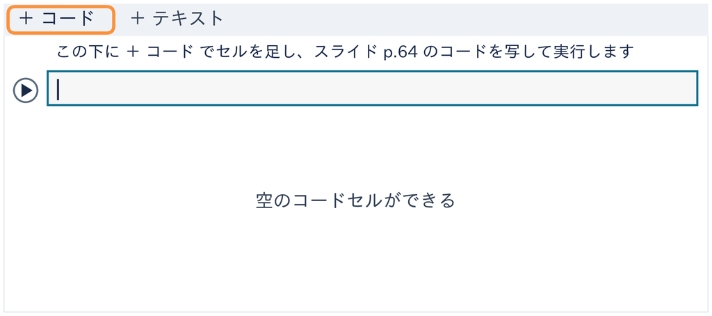

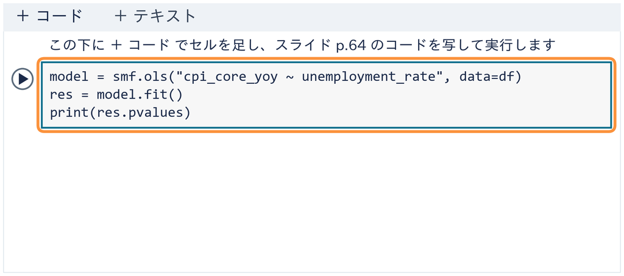

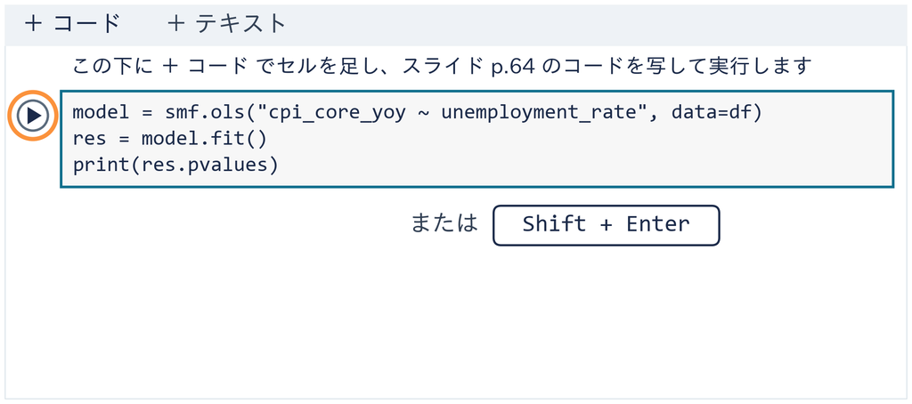

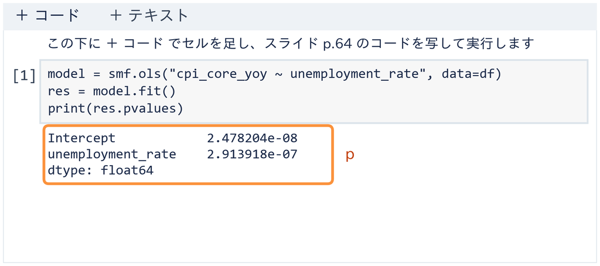

⏸ PAUSE 動画を止めて $2$ 分。$p$ が出たら再生に戻る

## 演習 4-3 期間別の $p$ 値

演習 4-3

2013〜2019 年の傾きは「偶然とは考えにくい」か

```python
model = smf.ols("cpi_core_yoy ~ unemployment_rate", data=d13)
res = model.fit()
print(res.pvalues)
```

1. **先に考える**（前の回に $R^2$ 0.02 の期間）：ⓐ 言える ⓑ 言えない
2. **写して変える**：写経の 3 行を写し、`data=df` を `data=d13` に  
   （`d13`：準備のセルで作った 2013〜2019 年の表）
3. **終わり**：答え欄に ⓐ か ⓑ と、`unemployment_rate` の行の $p$

⏸ PAUSE 動画を止めて $3$ 分。答えを書いたら再生に戻る

## 演習 4-3 の答え

| 期間 | 傾き | $t$ | $p$ |
| --- | --- | --- | --- |
| 36 年 | $-0.859$ | $-6.36$ | $2.9 \times 10^{-7}$ |
| 2013〜2019 年 | $-0.11$ | $-0.31$ | $0.767$ |

答えは **ⓑ 言えない**。$p \approx 0.767$ は 5% よりずっと大きい → ③ 棄却しない

「有意でない」は関係が無い証明ではなく、**判別できない**だけ

## まとめ

| 仮説検定の 3 段 | ① 仮定 | ② 数える（$p$） | ③ 判定 |
| --- | --- | --- | --- |
| 3 人 | 本当の傾きは 0 | $2 \div 6 \approx 0.33$ | 捨てない |
| 5 人 | 本当の傾きは 0 | $8 \div 120 \approx 0.067$ | 捨てない |
| 36 年 | 本当の傾きは 0 | summary の $p$ $2.9 \times 10^{-7}$ | 棄却（有意） |

summary の読む順

①`coef` で符号と大きさを読む（$-0.859$）

②`std err` で揺れを読む（$0.135$）

③`t` と `P>|t|` で偶然かを読む（$-6.36$・`0.000`）

右端の 2 列 `[0.025 0.975]` は次のトピックで読む

経済データとプログラミングII

第4回 — Topic04

信頼区間

捨てられない基準は、どこからどこまで？

## 第4回の道のり

1

揺れを測る

実習：実行 データを読む準備

実習：実行 引き直しの実行

実習：写経 標準誤差

演習 4-1 期間別の標準誤差

2

揺れの何個分

実習：写経 $t$ 値

演習 4-2 期間別の $t$ 値

3

偶然か判定

実習：写経 $p$ 値

演習 4-3 期間別の $p$ 値

4

基準の範囲

いまココ — 基準を替えて検定し、**捨てられない基準の範囲**を出す

## このトピックで学ぶこと

- **傾き**：この回の傾きは、**回帰直線の傾き $b_1$**
- **何をやるか**：基準を 0 以外にも替えて仮説検定を回し、  
  捨てられない基準を集める
- **なぜ**：「0 ではない」だけでは、傾きがどれくらいかは分からない
- **出てくる所**：summary の右端 2 列。  
  論文やレポートの表の「95% 信頼区間」
- **進め方**：前半は 5 人の表だけ。後半で 36 年に同じ考え方を当てる

問い：捨てられない基準は、どこからどこまで？

## 基準を替える問い

|  | 傾き | 基準 0（関係が無い）は |
| --- | --- | --- |
| 5 人 | $-2.0$ | 捨てない（$p$ 0.067） |
| 36 年 | $-0.859$ | 捨てる（$p$ $2.9 \times 10^{-7}$） |

疑う人の言い分を替えてみる：本当の傾きが **−1** だったら？ **−5** だったら？  
その言い分も、データで捨てられるか

$t$ ＝（傾き − 基準）÷ 揺れ。**基準は 0 でなくてよい**。ここで初めて使う  
ことばでは：傾きが、言い分の値（基準）から、揺れ何個ぶん離れているか

基準を引くのは、言い分の値からの距離を測るため  
揺れで割るのは、ものさしをそろえるため

## ◼ 基準を替えた仮説検定

流れ

① 仮定する言い分を「本当の傾きは基準の値」に替える（帰無仮説）

② 数える自習時間から「基準 × バイト日数」を取り除き  
残りを並べ替えて数える

③ 判定する5% 以下なら捨てる。5% より大きければ捨てない

- **なぜ取り除く**：本当の傾きが基準の値なら、それが関係のある分  
  残りはバイト日数と関係が無いはず
- **残りの傾き**：いまの傾き − 基準（$t$ の式の「傾き − 基準」と同じ）  
  ことばでは、基準の分の関係を取り除いたあとに、まだ残っている傾き

## ② 基準 −1 の残りの表

基準 −1：取り除く「−1 × バイト日数」は、**1 × バイト日数を足す**のと同じ

| 人 | A | B | C | D | E | 傾き |
| --- | --- | --- | --- | --- | --- | --- |
| バイト日数 $x$（日） | 1 | 2 | 3 | 4 | 5 |  |
| 自習時間（時間） | 9 | 10 | 6 | 2 | 3 | $-2.0$ |
| ＋ 1 × バイト日数 | ＋1 | ＋2 | ＋3 | ＋4 | ＋5 |  |
| 残り | 10 | 12 | 9 | 6 | 8 | $-1.0$ |

残りの傾きは $-2.0 - (-1) = -1.0$. この残りを、5 人のあいだで並べ替える

## ② 基準 −1 の 120 通り

[figure not shown]

③ $26 \div 120 \approx 0.22$ は 5% より大きい → 基準 −1 は**捨てない ○**

## ✋ たしかめ 基準 0 の判定

たしかめ

基準 0 は捨てられるか

1. **ⓐ** 捨てない **ⓑ** 捨てる
2. 手がかり：基準 0 なら、取り除く分は 0  
   × バイト日数。残りの表は何になる？
3. 1 つ選んでから、次のページで答え合わせ

⏸ PAUSE 動画を止めて $1$ 分。選んだら再生に戻る

## たしかめの答え

残りの表は**元の 5 人そのもの** → 前のトピックと同じ 8 通り → **ⓐ 捨てない ○**

[figure not shown]

基準 −5 なら残りは 14・20・21・22・28、残りの傾き $+3.0$ → 2 通り → **捨てる ×**

**捨てる（棄却）**：「本当の傾きはその基準」という言い分を、データで退ける  
**捨てない（受け入れる）**：退けられなかっただけ。その基準が正しいと証明したのではない

## ② 基準を端から端まで

基準を細かく替えて、同じ数え方をコンピュータで回し、○× を置いていく

[figure not shown]

左右がそろわないのは、基準ごとに残りの表が違い  
並べ替えた傾きの散らばり方も違うため（前のページの上下 2 段）  
点が 5 つと少ないと、その違いが大きい

## ◼ 95% 信頼区間

定義

**95% 信頼区間**：5% の仮説検定で、**棄却されない基準の集まり**

- **今回は**：5 人は $-4.0$〜$+1.0$
- **読み方 1**：内側の基準は捨てられない。外側の基準は捨てる
- **読み方 2**：0 が区間の内側 ⇔ 前のトピックで 0 を捨てなかった（$p$ 0.067）
- **95% の意味**：同じ作り方で、標本を取り直して何度も区間を作ると  
  本当の傾きを外に出すのは 5%（理由は次のページ）

## ◼ 95% になる理由

本当の傾きを、仮に −1.5 とする（次のページの作り物の世界）

理由の鎖

①基準を本当の傾き −1.5 に置く＝言い分がちょうど正しい世界の検定

②残りは関係が無いので、120 通りのどれが出るかはくじと同じ  
「捨てる」に当たるのは 6 通り：$6 \div 120 = 0.05$ ＝ 20 回に 1 回

③捨てなかったときは、−1.5 は区間の内側  
（区間：捨てられない基準の集まり）

④だから区間が本当の傾きを外に出すのは 5%・内側に入れるのは 95%

95% は、この作り方を何度もくり返したときの割合  
次のページで、20 回作って確かめる

## 20 回作った 95% 信頼区間

本当の傾きを −1.5 と決めた作り物の世界から、5 人の標本を 20 回取り直す  
毎回、5 人と同じ作り方（基準ごとに並べ替えて数える）で区間を作り、上から並べる

[figure not shown]

本当の傾きを外に出したのは 20 本のうち 1 本. 1000 回取り直すと 54 回（約 5%）

## よくある失敗 95% の読み違い

✕ 95% の確率で入っている

本当の傾きが 95% の確率で  
$-4.0$〜$+1.0$ に入っている

95% という数が付いているので  
そう読みたくなる

○ 捨てられない基準の範囲

本当の傾きは 1 つに決まっていて  
入っているか、いないか

95% は**作り方の約束**

言い直すと「データと食い違わない（5% で捨てられない）基準の範囲」  
$p$ を「傾きが 0 である確率」と読むのと同じ向きの誤り

## 36 年の基準ごとの $t$

今度は 36 年で、同じ考え方を。並べ方が多すぎて全部は数えられないので  
summary の式の揺れと、「$t$ の大きさが 2 を超えたら捨てる」目安を使う  
（2 の出どころは、後の倍率のページ）

| 基準 | $t$ ＝（$-0.859$ − 基準）÷ $0.135$ | ±2 の内側か | 判定 |
| --- | --- | --- | --- |
| 0 | $-6.4$ | 外 | × |
| $-1$ | $+1.0$ | 内 | ○ |
| $-0.5$ | $-2.7$ | 外 | × |

$t$ の大きさが 2 以下の基準は捨てない。2 を超える基準は捨てる

## ★ 36 年の区間

[figure not shown]

$-0.859 \pm 2 \times 0.135$ → **$-1.129$〜$-0.589$**. 0 は区間の外（前のトピックの棄却と同じ）  
ことばでは：傾きから左右に、揺れ 2 個ぶんずつ広げた範囲  
（$t$ の大きさが 2 以下＝基準が傾きから揺れ 2 個ぶん以内）

summary の計算は、どの基準でも $t$ の散らばり方が同じとみなすので、区間は左右対称

## summary の右端 2 列

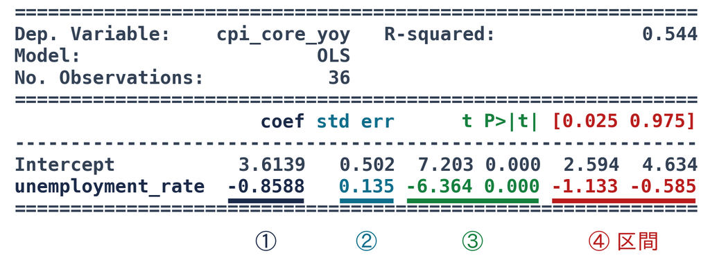

- **`[0.025 0.975]`**：$-1.133$〜$-0.585$. 外側 5% を左右に 2.5% ずつ分けた端
- **少し広い**：summary は 2 の代わりに 2.03 を使う  
  （なぜ点の数で倍率が変わるかは、次のページ）
- **0 が内側** ⇔ $p$ が 5% より大きい（棄却しない）。**外側** ⇔ 5% より小さい（棄却）

## ◼ 倍率 2・2.03・1.96

| 点の数 | 7 年 | 9 年 | 36 年 | とても多い（1000） |
| --- | --- | --- | --- | --- |
| 期間 | 2013〜2019 | 1991〜1999 | 全部 | — |
| 倍率 | 2.57 | 2.36 | 2.03 | 1.96 |

- **点が少ないほど倍率が大きい**：区間を広く取る  
  （式の揺れそのものが揺れる分を見込む）
- **点がとても多いと 1.96 に近づく**：ちょうど 95% が内側に入る幅
- **2 は 1.96 を丸めた目安**：内側は 95.4%（36 年の基準ごとの $t$ で使った ±2）

## 36 年の 3 本の帯

[figure not shown]

36 年なら、どれで作ってもほとんど同じ。どれも 0 は外

## まとめ

- 揺れを測る：**標準誤差**（36 年の `std err` 0.135）
- 基準から揺れの何個分：**$t$ 値**（基準 0 で $-6.36$）
- 仮定を置いて判定：**仮説検定**（$p$ が 5% 以下なら棄却）
- 基準を替えて、捨てられない基準を集める：**95% 信頼区間**  
  （36 年 $-1.13$〜$-0.58$）

引いた線の傾きは、標本ごとに揺れる  
揺れの幅を測って初めて「偶然とは考えにくい」と言える